# Lesson9

Emi

2026-07-07

```r
suppressPackageStartupMessages(library(tidyverse))
suppressPackageStartupMessages(library(knitr))

coronavirus <- read_csv('https://raw.githubusercontent.com/RamiKrispin/coronavirus/master/csv/coronavirus.csv', col_types = cols(province = col_character()))

# Has it been updated? Check the latest date?
max(coronavirus$date)
```

```
## [1] "2023-01-04"
```

```r
View(coronavirus)
```

###Let’s start with summarizing the total number of cases by type as of the most recent day in the dataset

```r
names(coronavirus)
```

```
##  [1] "date"           "province"       "country"        "lat"
##  [5] "long"           "type"           "cases"          "uid"
##  [9] "iso2"           "iso3"           "code3"          "combined_key"
## [13] "population"     "continent_name" "continent_code"
```

```r
cases <- coronavirus %>% group_by(type) %>%
  summarize(cases = sum(cases))
kable(cases) # kable() just provides a nice output for the table
```

| type | cases |
| --- | --- |
| confirmed | 662136356 |
| death | 7507951 |
| recovery | 0 |

###Now, let’s plot the history of the daily counts of new confirmed cases worldwide

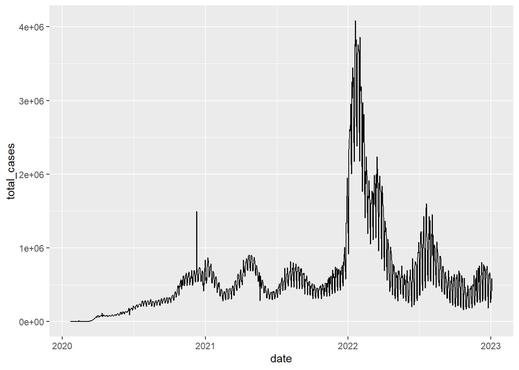

```r
# We first have to summarize the data, then plot those summary statistics
# Note that we can pipe dplyr output directly into ggplot
coronavirus %>%
  filter(type == "confirmed") %>%
  group_by(date) %>%
  summarize(total_cases = sum(cases)) %>%
  ggplot(mapping = aes(x = date, y = total_cases)) +
  geom_line()
```

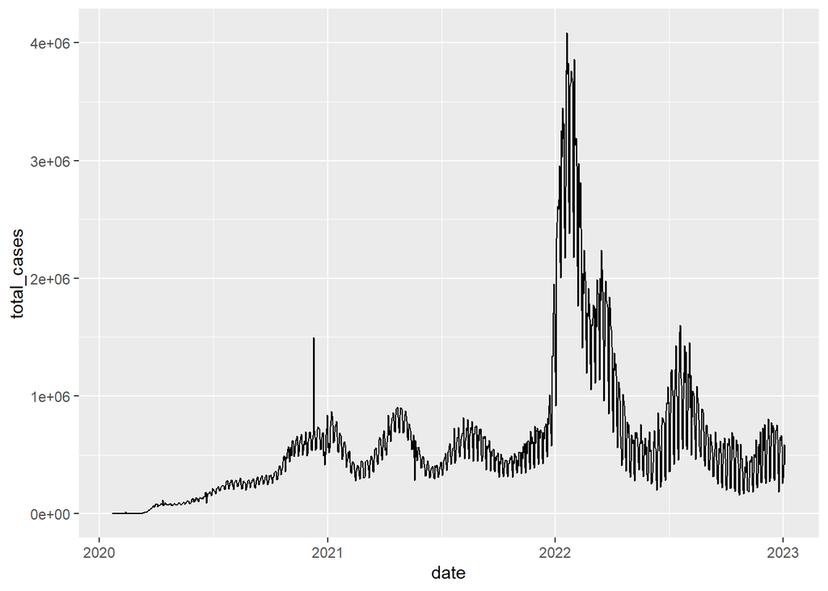

```r
# If we want to play around with different geoms, we can store dplyr data processing steps and initiation of the ggplot as object gg_base so that we don’t need to retype it each time

# define a base map dataset
gg_base <- coronavirus %>%
  filter(type == "confirmed") %>%
  group_by(date) %>%
  summarize(total_cases = sum(cases)) %>%
  ggplot(mapping = aes(x = date, y = total_cases))

# line
gg_base +
  geom_line()
```

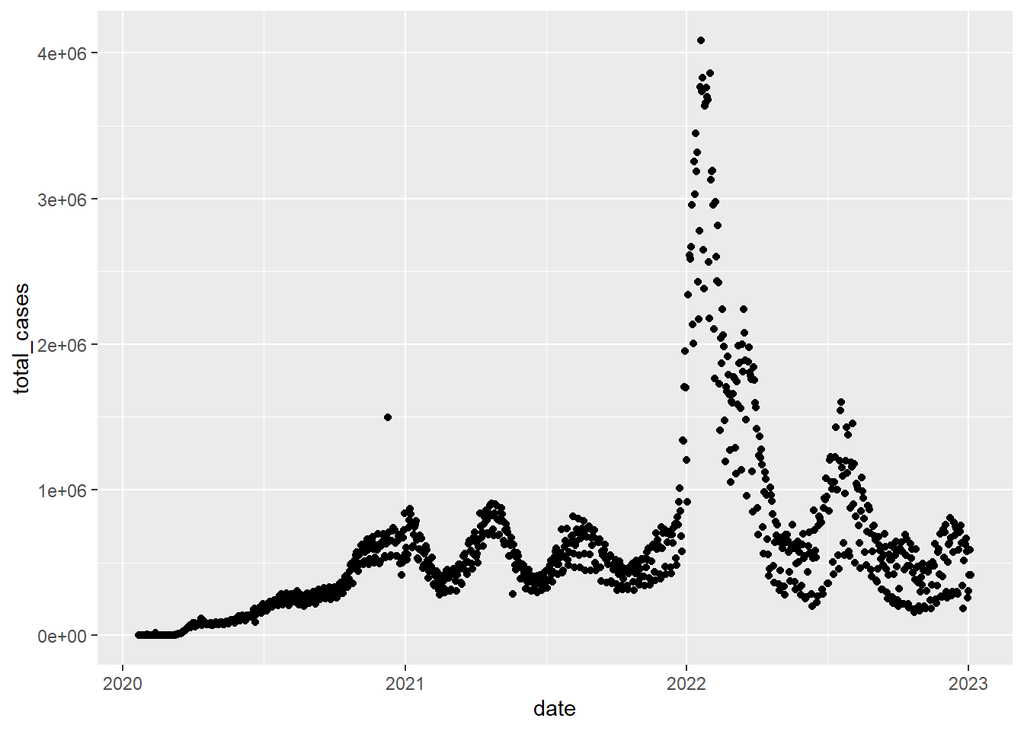

```r
# point
gg_base +
  geom_point()
```

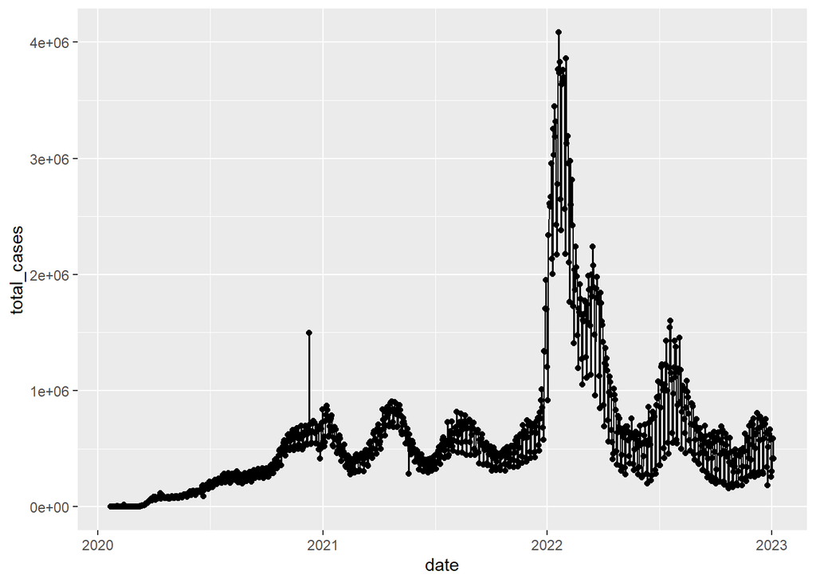

```r
# line and point
gg_base +
  geom_line() +
  geom_point()
```

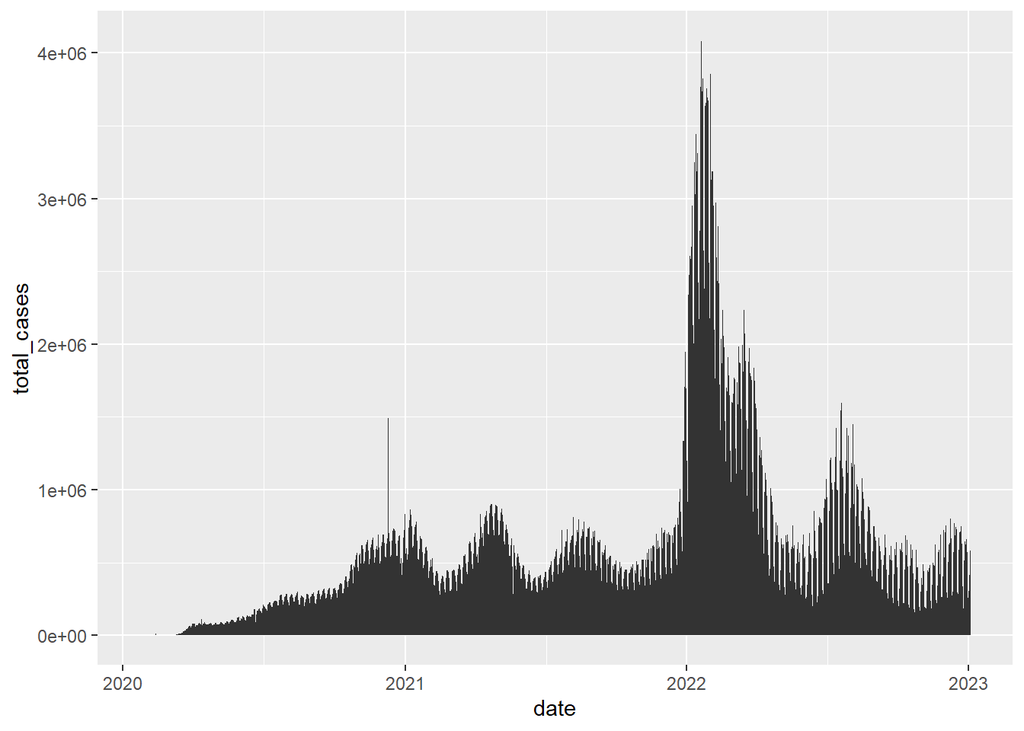

```r
# area
gg_base +
  geom_area()
```

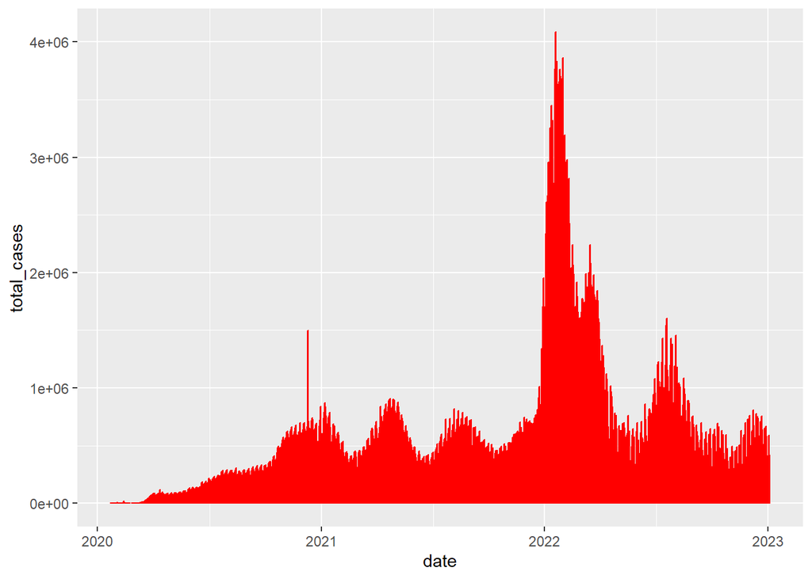

```r
gg_base +
  geom_col(color="red")
```

### We can change the aesthetics of elements in a ggplot graph by adding arguments within the layer where that element is created. Some common arguments we’ll use first are:

####color =: update point or line colors ####fill =: update fill color for objects with areas ####linetype =: update the line type (dashed, long dash, etc.) ####pch =: update the point style ####size =: update the element size (e.g. of points or line thickness) ####alpha =: update element opacity (1 = opaque, 0 = transparent) #####Building on our first line graph, let’s update the line color to “purple” and make the line type “dashed”:

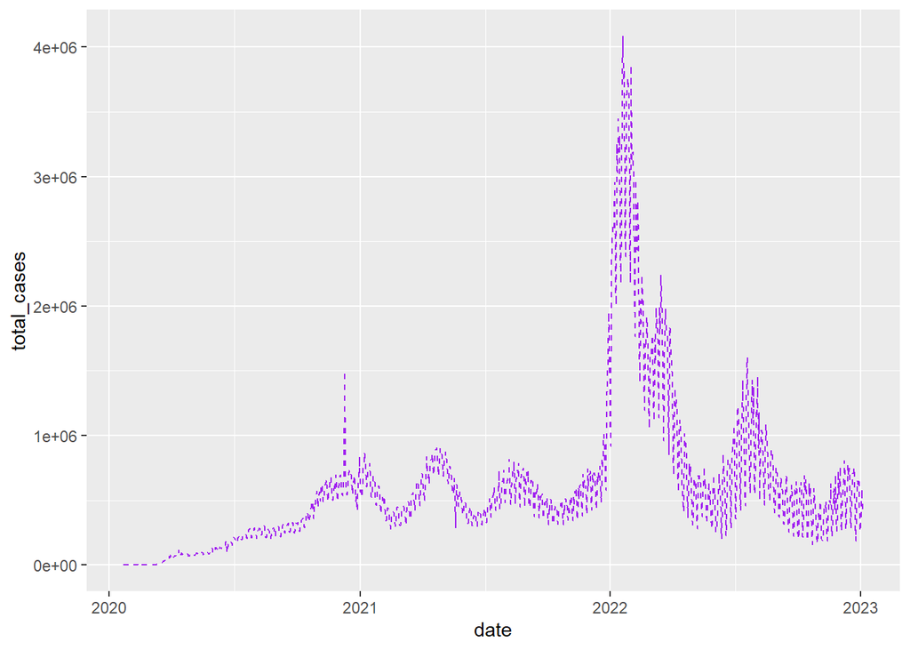

```r
gg_base +
  geom_line(
    color = "purple",
    linetype = "dashed"
  )
```

###How do we know which color names ggplot will recognize? If you google “R colors ggplot2” you’ll find a lot of good resources. Here’s one: SAPE ggplot2 colors quick reference guide

###Now let’s update the point, style and size of points on our previous scatterplot graph using color =, size =, and pch = (see ?pch for the different point styles, which can be further customized).

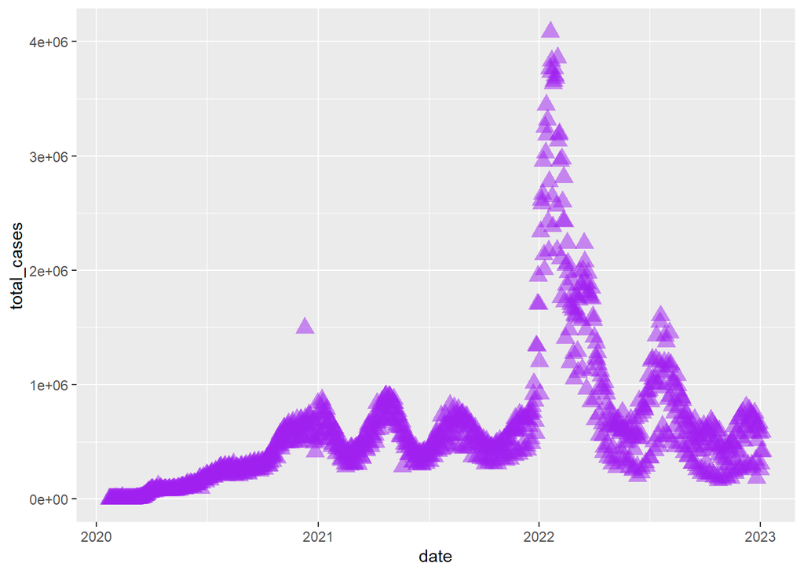

```r
gg_base +
  geom_point(color = "purple",
             pch = 17,
             size = 4,
             alpha = 0.5)
```

###Example: Create a ggplot scatterplot graph where the size and color of the points change based on the number of cases, and make all points the same level of opacity (alpha = 0.5). Notice the aes() around the size = and color = arguments.

###Note: this is just for illustration of the functionality only - we are showing the same information in redundant ways, which is typically not helpful or necessary. Avoid excessive / overcomplicated aesthetic mapping in data visualization.

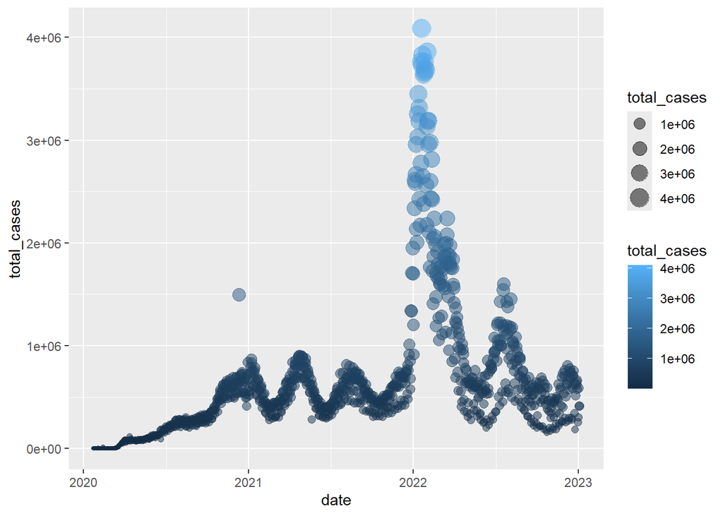

```r
gg_base +
  geom_point(
    aes(size = total_cases,
        color = total_cases),
    alpha = 0.5
  )
```

```r
#In the example above, notice that the two arguments that do depend on variables are within aes(), but since alpha = 0.5 doesn’t depend on a variable then it is outside the aes() but still within the geom_point() layer.
```

###While every element of a ggplot graph is manually customizable, there are also built-in themes (theme_*()) that you can add to your ggplot code to make some major headway before making smaller tweaks manually.

###We talked about this briefly a few classes ago, but let’s explore a little further. Here are a few to try today (but also notice all the options that appear as we start typing theme_ into our ggplot graph code!):

####theme_light() ####theme_minimal() ####theme_bw() ####Also, check out more examples by scrolling down here. Pick one that you like and update your previous plot.

#####Here, let’s update our previous graph with theme_minimal():

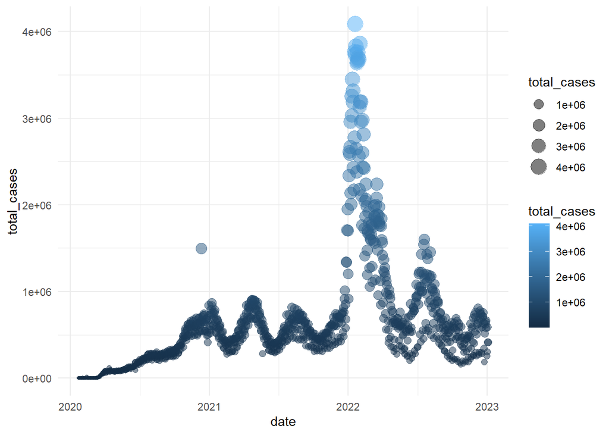

```r
gg_base +
  geom_point(
    aes(size = total_cases,
        color = total_cases),
    alpha = 0.5
  ) +
  theme_minimal()
```

##Updating axis labels and titles ###Use labs() to update axis labels, and add a title and/or subtitle to your ggplot graph.

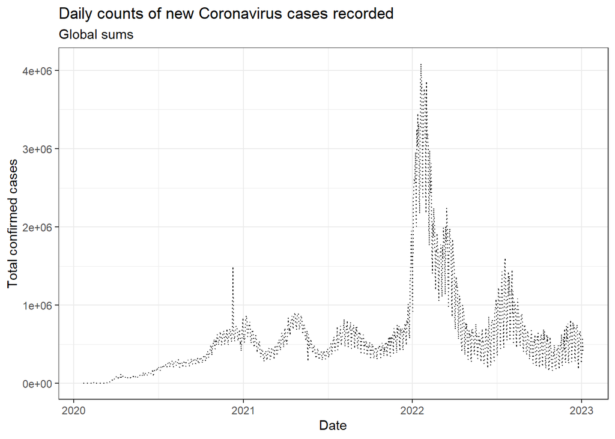

```r
gg_base +
  geom_line(linetype = "dotted") +
  theme_bw() +
  labs(
    x = "Date",
    y = "Total confirmed cases",
    title = "Daily counts of new Coronavirus cases recorded",
    subtitle = "Global sums"
  )
```

#Now, let’s split the case counts out by country

###Your turn ####Take a minute to think about how you would generate a plot with a separate line showing the daily reports of new confirmed cases in each country.

```
## `summarise()` has regrouped the output.
## ℹ Summaries were computed grouped by country and date.
## ℹ Output is grouped by country.
## ℹ Use `summarise(.groups = "drop_last")` to silence this message.
## ℹ Use `summarise(.by = c(country, date))` for per-operation grouping
##   (`?dplyr::dplyr_by`) instead.
```

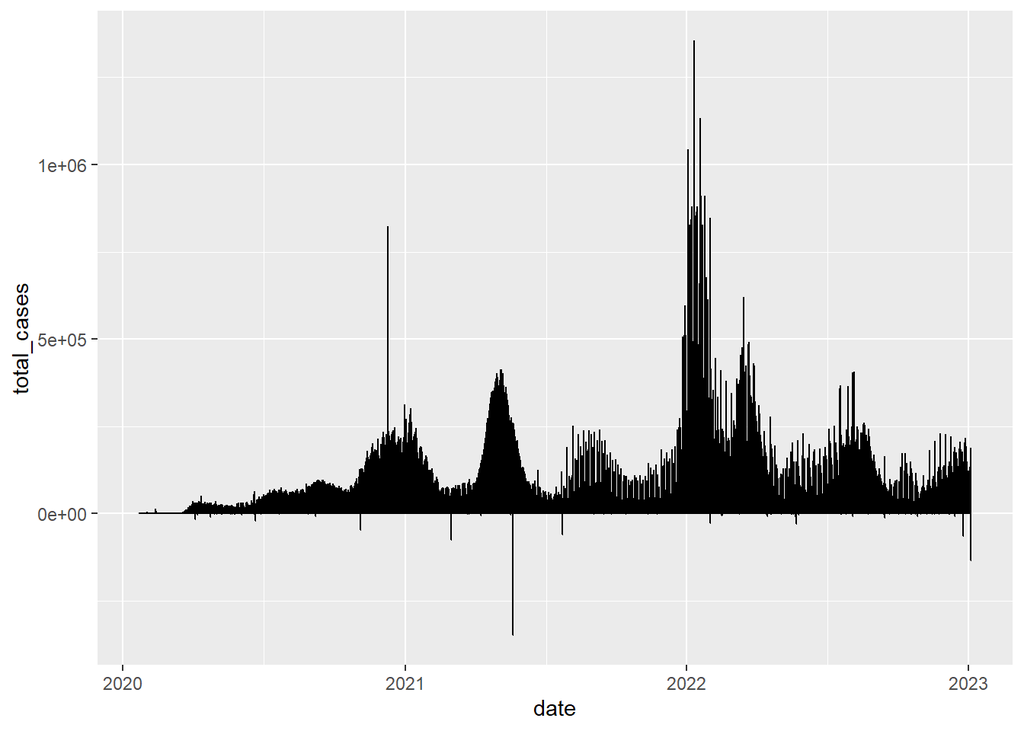

```r
# We need columns date, country, and type = confirmed

######this code below will not work:
#coronavirus %>%
   #filter(type == "confirmed") %>%
 # group_by(date) %>%
 # summarize(total_cases = sum(cases)) %>%
  #ggplot() +
  #geom_line(mapping = aes(x = date, y = total_cases, color = country))
########### We have summarized out the country details (only one total count per day)


coronavirus %>%
  filter(type == "confirmed") %>%
  group_by(country, date) %>%
  summarize(total_cases = sum(cases)) %>%
  ggplot(mapping = aes(x = date, y = total_cases)) +
  geom_line()
```

```r
# Even though we have grouped the dataframe by country, that dplyr grouping does not get carried into ggplot
```

```
## `summarise()` has regrouped the output.
## ℹ Summaries were computed grouped by country and date.
## ℹ Output is grouped by country.
## ℹ Use `summarise(.groups = "drop_last")` to silence this message.
## ℹ Use `summarise(.by = c(country, date))` for per-operation grouping
##   (`?dplyr::dplyr_by`) instead.
```

[figure not shown]

```r
#Now let’s make ggplot group the data too by mapping country onto an aesthetic
coronavirus %>%
  filter(type == "confirmed") %>%
  group_by(country, date) %>%
  summarize(total_cases = sum(cases)) %>%
  ggplot(mapping = aes(x = date, y = total_cases, color = country)) +
  geom_line()
```

```
## `summarise()` has regrouped the output.
## ℹ Summaries were computed grouped by country and date.
## ℹ Output is grouped by country.
## ℹ Use `summarise(.groups = "drop_last")` to silence this message.
## ℹ Use `summarise(.by = c(country, date))` for per-operation grouping
##   (`?dplyr::dplyr_by`) instead.
```

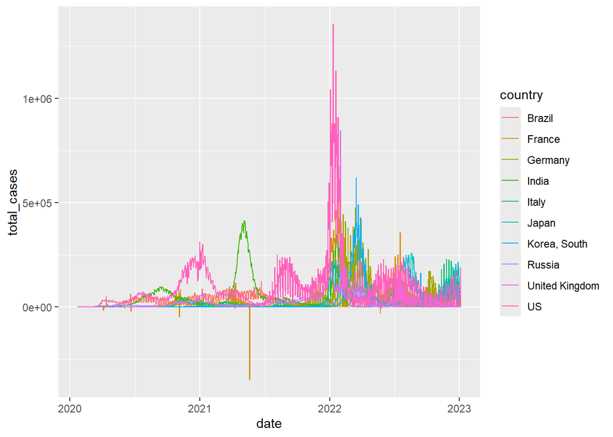

```r
#It looks like this is doing what we want, but it does not display well. There are too many countries! We could play around with the layout parameters to be able to see this plot. But let’s instead subset to only show the 10 countries with the highest total counts of confirmed cases.

top10_countries <- coronavirus %>%
  filter(type == "confirmed") %>%
  group_by(country) %>%
  summarize(total_cases = sum(cases)) %>%
  arrange(-total_cases) %>%
  head(10) %>%
  .$country

View(top10_countries)

#Now let’s try to plot the daily counts of new cases just for those countries
coronavirus %>%
  filter(type == "confirmed", country %in% top10_countries) %>%
  group_by(country, date) %>%
  summarize(total_cases = sum(cases)) %>%  # Need this summarize because some countries have data broken down by Province.State
  ggplot(mapping = aes(x = date, y = total_cases, color = country)) +
  geom_line()
```

```
## `summarise()` has regrouped the output.
## ℹ Summaries were computed grouped by country and date.
## ℹ Output is grouped by country.
## ℹ Use `summarise(.groups = "drop_last")` to silence this message.
## ℹ Use `summarise(.by = c(country, date))` for per-operation grouping
##   (`?dplyr::dplyr_by`) instead.
```

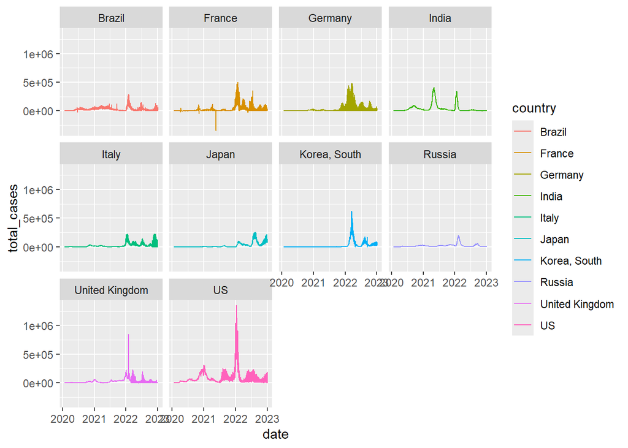

```r
#We can also make a separate panel for each country

coronavirus %>%
  filter(type == "confirmed", country %in% top10_countries) %>%
  group_by(country, date) %>%
  summarize(total_cases = sum(cases)) %>%
  ggplot(mapping = aes(x = date, y = total_cases, color = country)) +
  geom_line() +
  facet_wrap(~country)
```

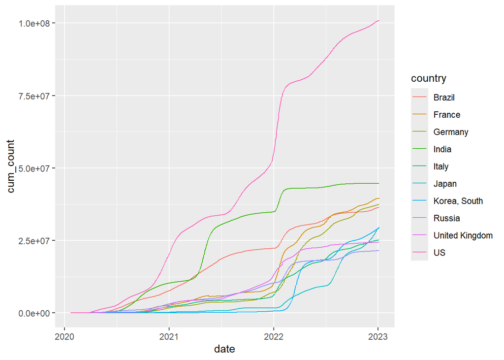

```r
#Now let’s plot the cumulative sum of cases for each of those countries instead


coronavirus %>%
  filter(type == "confirmed", country %in% top10_countries) %>%
  group_by(country) %>%
  arrange(date) %>%
  mutate(cum_count = cumsum(cases)) %>%
  ggplot(mapping = aes(x = date, y = cum_count, color = country)) +
  geom_line()
```

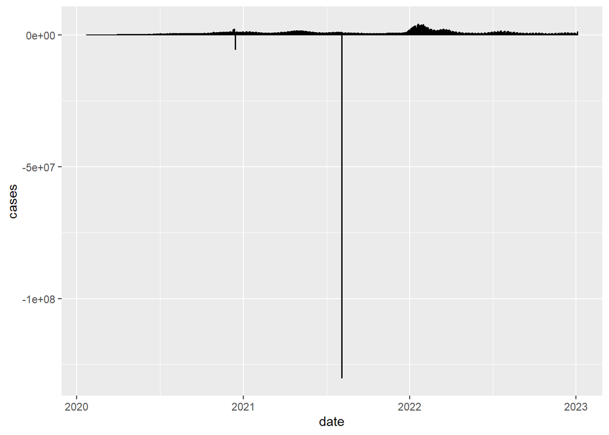

```r
#Another common plot type are bar charts. There are two types of bar charts in ggplot: geom_bar() and geom_col(). geom_bar() makes the height of the bar proportional to the number of cases in each group (or if the weight aesthetic is supplied, the sum of the weights). If you want the heights of the bars to represent values in the data, use geom_col() instead.

#Since our dataset reports counts of cases, let’s first start with geom_col() (we have already used it once today).

coronavirus %>%
  group_by(date) %>%
  summarize(cases = sum(cases)) %>%
  ggplot() +
  geom_col(aes(x = date, y = cases), color = "black")
```

```r
#wut the heck. Why are there negative cases. This dataset seems skewwed, the negatives can be removed for a
#better picture but why are they there to begin with
```

```
## `summarise()` has regrouped the output.
## ℹ Summaries were computed grouped by date and type.
## ℹ Output is grouped by date.
## ℹ Use `summarise(.groups = "drop_last")` to silence this message.
## ℹ Use `summarise(.by = c(date, type))` for per-operation grouping
##   (`?dplyr::dplyr_by`) instead.
```

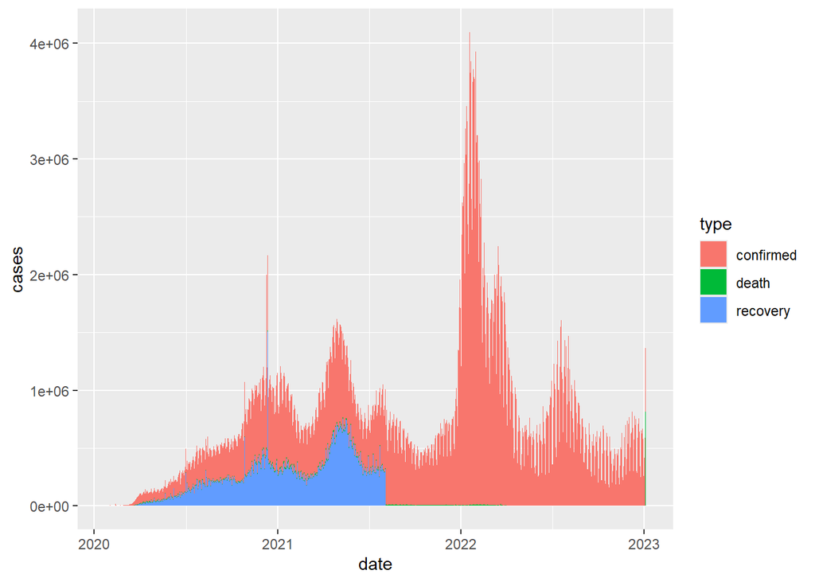

```r
#If we want a stacked barplot separating out the different types of cases, we can use the fill aesthetic

coronavirus %>%
  group_by(date, type) %>% filter(cases > 0) %>%
  summarize(cases = sum(cases)) %>%
  ggplot() +
  geom_col(aes(x = date, y = cases, fill = type), size=0.1)
```

```
## `summarise()` has regrouped the output.
## ℹ Summaries were computed grouped by date and type.
## ℹ Output is grouped by date.
## ℹ Use `summarise(.groups = "drop_last")` to silence this message.
## ℹ Use `summarise(.by = c(date, type))` for per-operation grouping
##   (`?dplyr::dplyr_by`) instead.
```

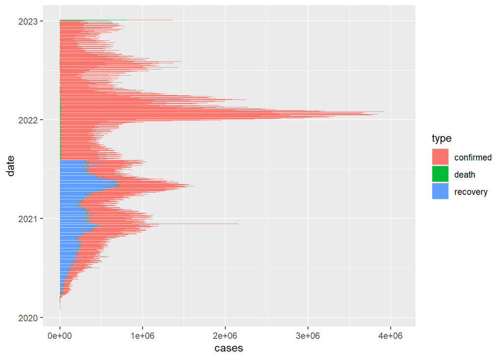

```r
#flip!
coronavirus %>%
  group_by(date, type) %>% filter(cases > 0) %>%
  summarize(cases = sum(cases)) %>%
  ggplot() +
  geom_col(aes(x = date, y = cases, fill = type), size=0.1) +
  coord_flip()
```

```
## `summarise()` has regrouped the output.
## ℹ Summaries were computed grouped by date and type.
## ℹ Output is grouped by date.
## ℹ Use `summarise(.groups = "drop_last")` to silence this message.
## ℹ Use `summarise(.by = c(date, type))` for per-operation grouping
##   (`?dplyr::dplyr_by`) instead.
```

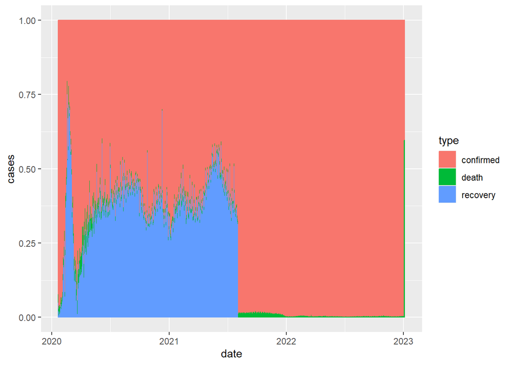

```r
#This is useful because it puts the proportions in relation to the total daily counts. But it can be hard to compare proportions. We can make all bars the same height with ‘position adjustment’

coronavirus %>% filter(cases > 0) %>%
  group_by(date, type) %>%
  summarize(cases = sum(cases)) %>%
  ggplot() +
  geom_col(aes(x=date, y = cases, fill = type, color = type), size=0.1, position = "fill")
```

Let’s check if we have negative cases.

```r
coronavirus %>%
  filter(cases < 0)
```

```
## # A tibble: 1,166 × 15
##    date       province  country   lat   long type  cases   uid iso2  iso3  code3
##    <date>     <chr>     <chr>   <dbl>  <dbl> <chr> <dbl> <dbl> <chr> <chr> <dbl>
##  1 2020-03-25 Alberta   Canada   53.9 -117.  conf…    -1 12401 CA    CAN     124
##  2 2022-10-19 Aruba     Nether…  12.5  -70.0 conf…  -854   533 AW    ABW     533
##  3 2020-04-13 Australi… Austra… -35.5  149.  conf…    -1  3601 AU    AUS      36
##  4 2022-01-07 Australi… Austra… -35.5  149.  conf…  -124  3601 AU    AUS      36
##  5 2022-01-20 Australi… Austra… -35.5  149.  conf…   -38  3601 AU    AUS      36
##  6 2022-07-31 Australi… Austra… -35.5  149.  conf…   -16  3601 AU    AUS      36
##  7 2022-09-09 Australi… Austra… -35.5  149.  conf…  -106  3601 AU    AUS      36
##  8 2022-09-16 Australi… Austra… -35.5  149.  conf…   -74  3601 AU    AUS      36
##  9 2022-11-29 Australi… Austra… -35.5  149.  conf… -2678  3601 AU    AUS      36
## 10 2021-06-28 Beijing   China    40.2  116.  conf…    -1 15602 CN    CHN     156
## # ℹ 1,156 more rows
## # ℹ 4 more variables: combined_key <chr>, population <dbl>,
## #   continent_name <chr>, continent_code <chr>
```

```
## `summarise()` has regrouped the output.
## ℹ Summaries were computed grouped by date and type.
## ℹ Output is grouped by date.
## ℹ Use `summarise(.groups = "drop_last")` to silence this message.
## ℹ Use `summarise(.by = c(date, type))` for per-operation grouping
##   (`?dplyr::dplyr_by`) instead.
```

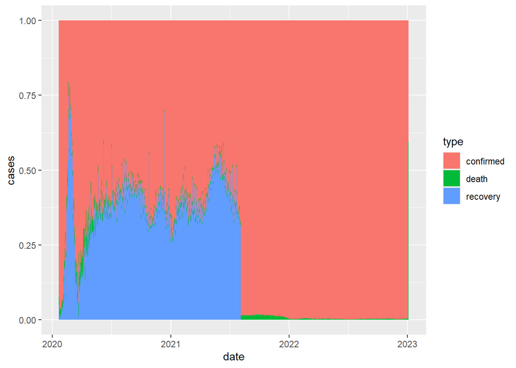

```r
#we already did this above but ok
# Let's remove those
coronavirus %>%
  filter(cases > 0) %>%
  group_by(date, type) %>%
  summarize(cases = sum(cases)) %>%
  ggplot() +
  geom_col(aes(x = date, y = cases, fill = type), size=0.1, position = "fill")
```

We can also get the bars for the different types of cases each day stacked next to each other with another position adjustment option

```
## `summarise()` has regrouped the output.
## ℹ Summaries were computed grouped by date and type.
## ℹ Output is grouped by date.
## ℹ Use `summarise(.groups = "drop_last")` to silence this message.
## ℹ Use `summarise(.by = c(date, type))` for per-operation grouping
##   (`?dplyr::dplyr_by`) instead.
```

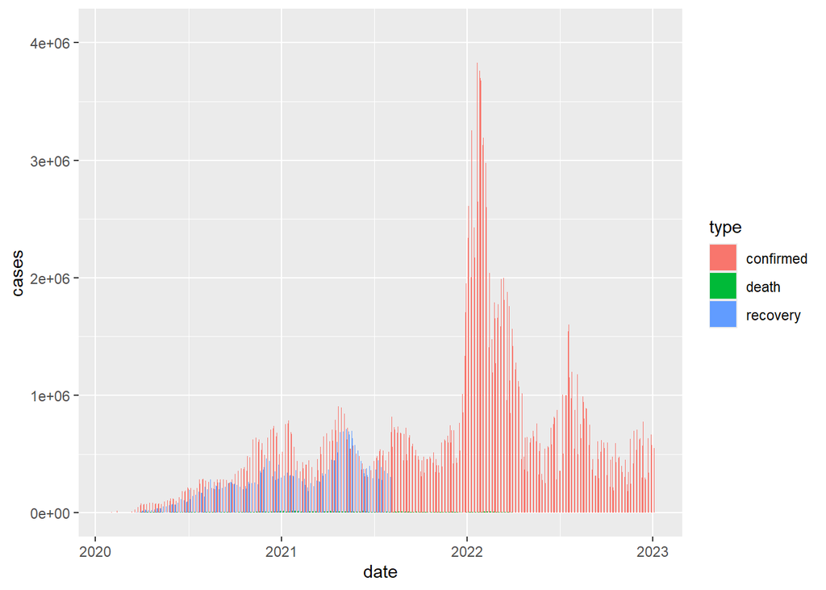

```r
coronavirus %>%
  filter(cases > 0) %>%
  group_by(date, type) %>%
  summarize(cases = sum(cases)) %>%
  ggplot() +
  geom_col(aes(x = date, y = cases, fill = type), position = "dodge")
```

Now, let’s break it down by country. Let’s again subset to only the top 10 countries with the highest counts

```
## `summarise()` has regrouped the output.
## ℹ Summaries were computed grouped by country, type, and date.
## ℹ Output is grouped by country and type.
## ℹ Use `summarise(.groups = "drop_last")` to silence this message.
## ℹ Use `summarise(.by = c(country, type, date))` for per-operation grouping
##   (`?dplyr::dplyr_by`) instead.
```

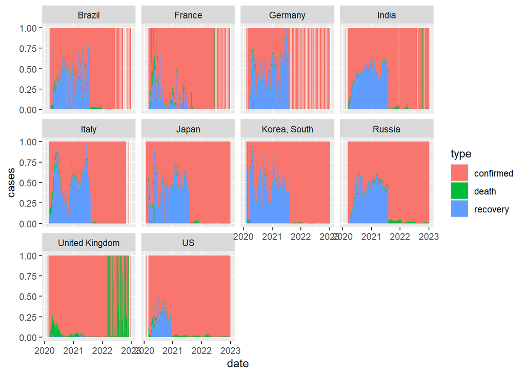

```r
coronavirus %>%
  filter(cases > 0, country %in% top10_countries) %>%
  group_by(country, type, date) %>%
  summarize(cases = sum(cases)) %>%
  ggplot() +
  geom_col(aes(x = date, y = cases, fill = type), position = "fill", width = 1) +
  facet_wrap(~country)
```

While looking at the proportions of case types in different areas is helpful for comparing patterns, they don’t allow for comparison of the magnitude of case counts. Let’s again scale the bars by the raw case counts.

```
## `summarise()` has regrouped the output.
## ℹ Summaries were computed grouped by country, type, and date.
## ℹ Output is grouped by country and type.
## ℹ Use `summarise(.groups = "drop_last")` to silence this message.
## ℹ Use `summarise(.by = c(country, type, date))` for per-operation grouping
##   (`?dplyr::dplyr_by`) instead.
```

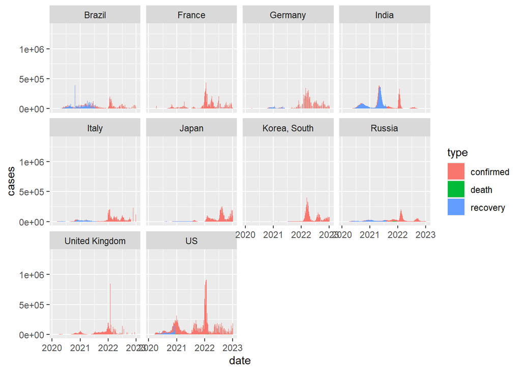

```r
coronavirus %>%
  filter(cases > 0, country %in% top10_countries) %>%
  group_by(country, type, date) %>%
  summarize(cases=sum(cases)) %>%
  ggplot() +
  geom_col(aes(x=date, y = cases, fill = type), position = "identity", width = 1) +
  facet_wrap(~country)
```

Now, let’s explore a different question. For each day, let’s plot how many different countries have at least one new confirmed case. For this we will need to count rows within grouped variables, so we’ll use the geom_bar()

```
## `summarise()` has regrouped the output.
## ℹ Summaries were computed grouped by country and date.
## ℹ Output is grouped by country.
## ℹ Use `summarise(.groups = "drop_last")` to silence this message.
## ℹ Use `summarise(.by = c(country, date))` for per-operation grouping
##   (`?dplyr::dplyr_by`) instead.
```

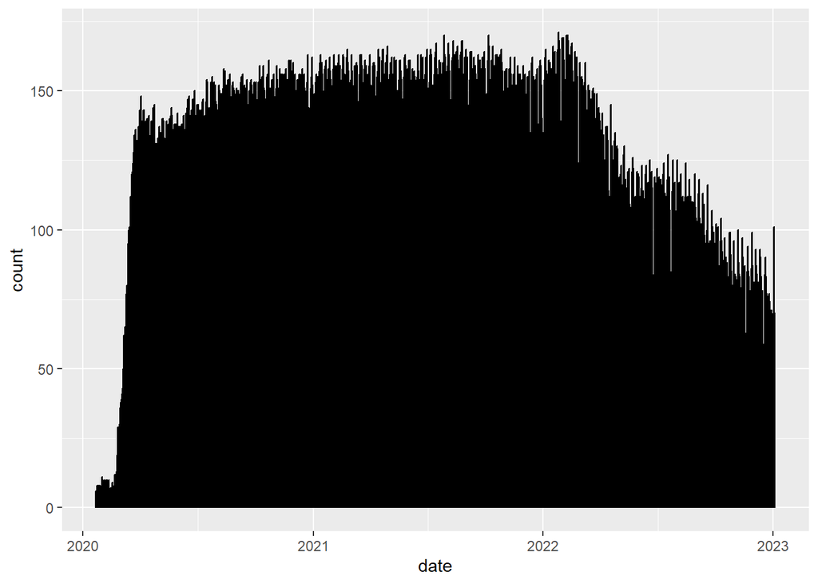

```r
#How many countries have at least one confirmed case each day
coronavirus %>%
  filter(type == "confirmed") %>%
  group_by(country, date) %>%
  summarize(total_cases = sum(cases)) %>%
  filter(total_cases > 0) %>%
  ggplot() +
  geom_bar(mapping = aes(x = date), color="black")
```

Now let’s look at the relationship between confirmed cases and deaths in each country. For this we will need our re-formatted wide data from last class.

```r
coronavirus_ttd <- coronavirus %>%
  select(country, type, cases) %>%
  group_by(country, type) %>%
  summarize(total_cases = sum(cases)) %>%
  pivot_wider(names_from = type,
              values_from = total_cases) %>%
  arrange(-confirmed)
```

```
## `summarise()` has regrouped the output.
## ℹ Summaries were computed grouped by country and type.
## ℹ Output is grouped by country.
## ℹ Use `summarise(.groups = "drop_last")` to silence this message.
## ℹ Use `summarise(.by = c(country, type))` for per-operation grouping
##   (`?dplyr::dplyr_by`) instead.
```

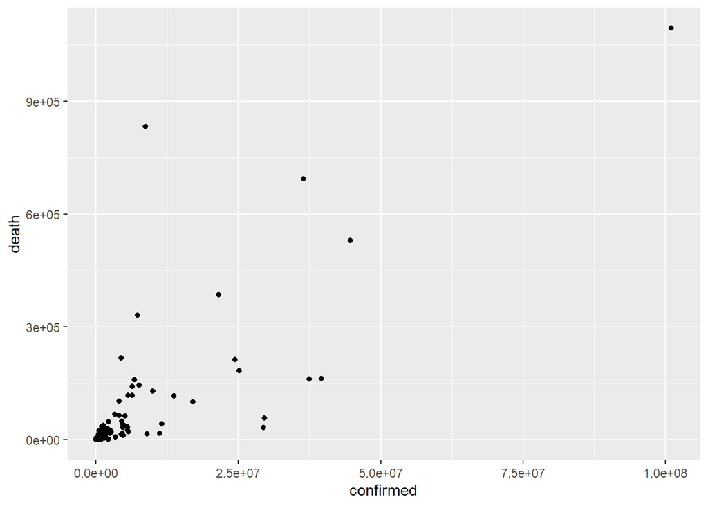

```r
ggplot(coronavirus_ttd) +
  geom_point(mapping = aes(x = confirmed, y = death))
```

It is useful to know which country is represented by each dot. geom_label is our tool for that.

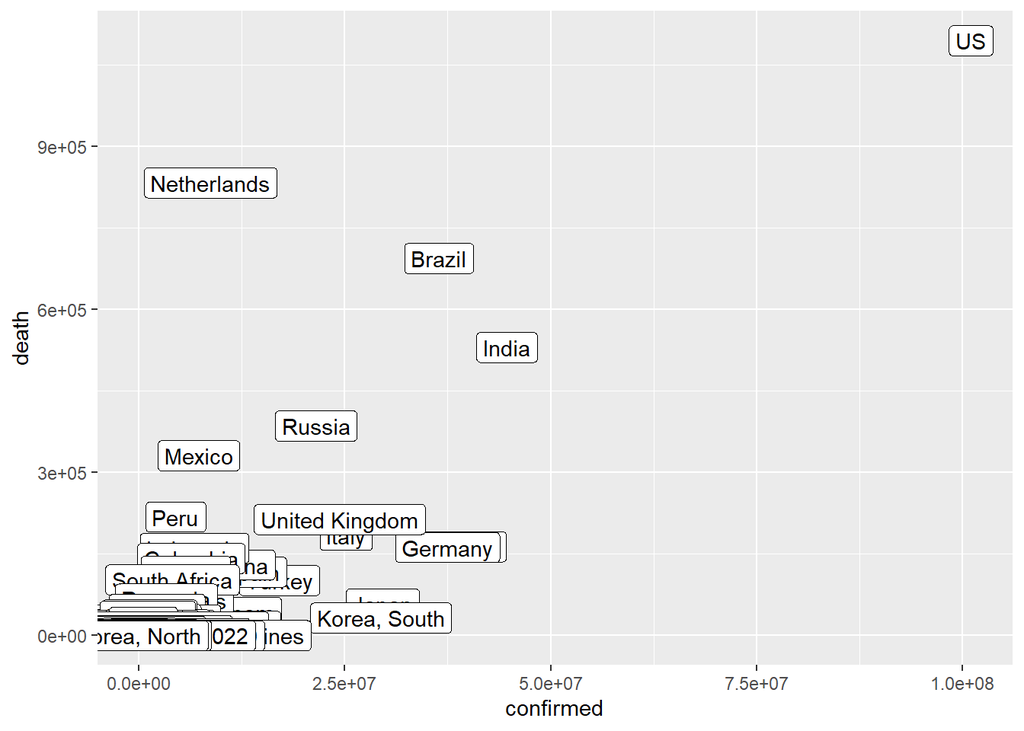

```r
ggplot(coronavirus_ttd) +
  geom_label(mapping = aes(x = confirmed, y = death, label = country))
```

Let’s do a few things to make this easier to read

We can remove countries with a small number of confirmed cases

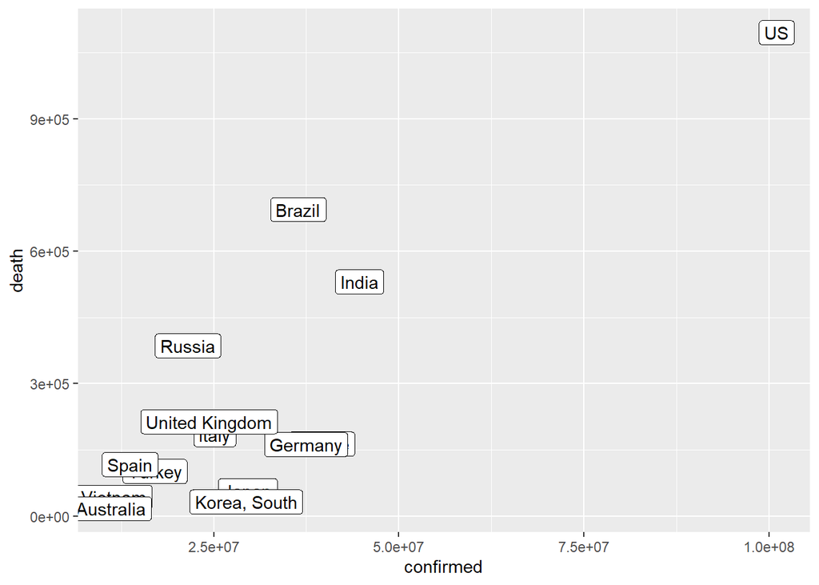

```r
ggplot(data = filter(coronavirus_ttd, confirmed > 10000000)) +
  geom_label(mapping = aes(x = confirmed, y = death, label = country))
```

We can remove the area with low confirmed case count from the plot

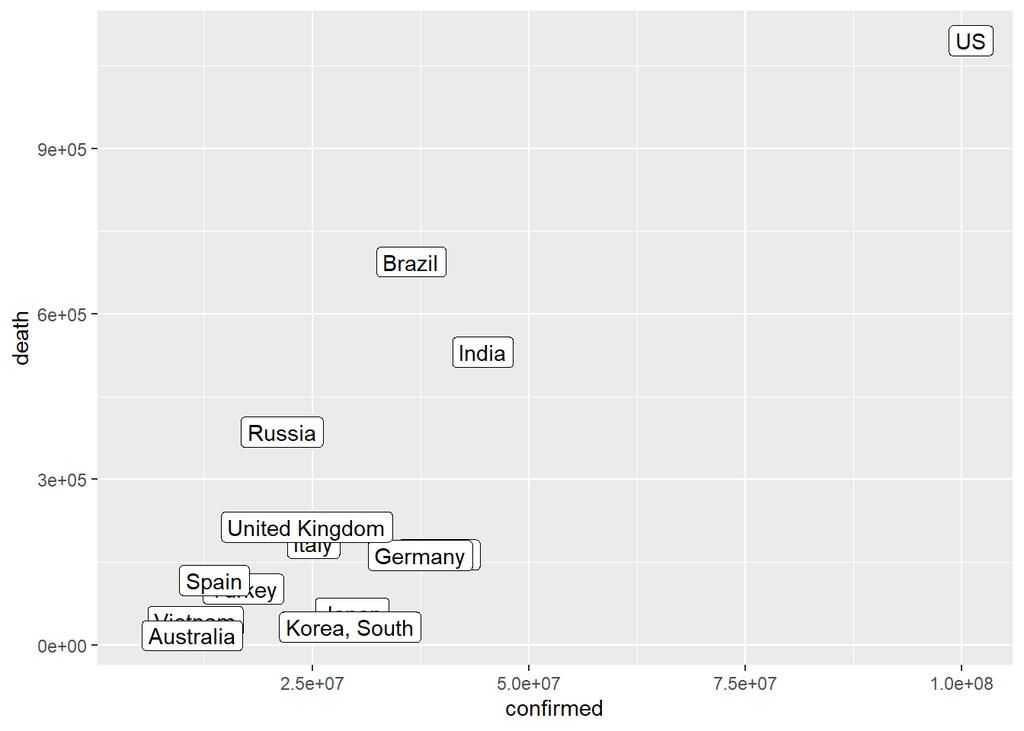

```r
ggplot(data = filter(coronavirus_ttd, confirmed > 10000000)) +
  geom_label(mapping = aes(x = confirmed, y = death, label = country)) +
  xlim(5000000, max(coronavirus_ttd$confirmed))
```

Or zoom in on that region

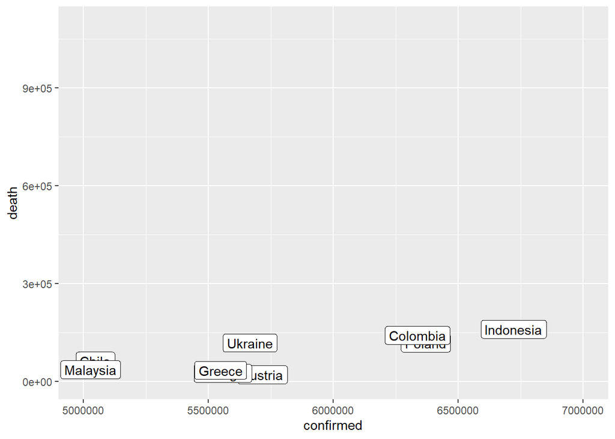

```r
ggplot(data = filter(coronavirus_ttd)) +
  geom_label(mapping = aes(x = confirmed, y = death, label = country)) +
  xlim(5000000, 7000000)
```

Map of newly reported cases With some additional packages, we can also plot geographical patterns on a map. We can, for example, show which countries have new counts of >5000 new confirmed cases on the most recent day from this dataset and scale the points with case counts.

```r
library("rnaturalearth") # install.packages("rnaturalearth")
library("rnaturalearthdata") # install.packages("rnaturalearthdata")
library("sf") #install.packages("sf")
#RGEOS WAS FULLY RETIRED IN 2023, MUST US SF LIBRARY: library("rgeos") # install.packages("rgeos")
```

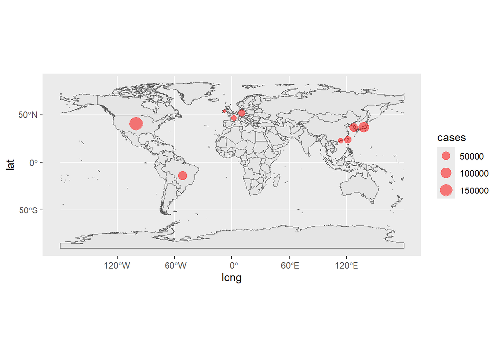

```r
world <- ne_countries(scale = "medium", returnclass = "sf")
filter(coronavirus, date == max(coronavirus$date), type == "confirmed", cases > 5000) %>%
  ggplot() +
  geom_sf(data = world) +
  geom_point(aes(x=long, y=lat, size=cases), color="red", fill="red", alpha=0.5, shape=21)
```

See following lesson for more exercises/clarity when trying to use this code and these functions: https://nt246.github.io/NTRES6940-data-science/lesson9-ggplot-part2.html#combining_dplyr_and_ggplot